# Alliance ACO Progress Report

Northern Arizona Regional Behavioral Health Alliance Accountable Care Organization

Author

John Ryan Kivela, MA

Published

July 27, 2023

# Introduction

The Northern Arizona Regional Behavioral Health Alliance (NARBHA), hereafter “The Alliance”, is a collaborative project between The Narbha Institute (TNI) and Blue Cross Blue Shield of Arizona (BCBSAZ). It is a first of its kind Behavioral Health Accountable Care Organization (ACO), specifically created to improve the health outcomes of disadvantaged people in rural Arizona. The focus of the Alliance is quality improvement and member satisfaction in our rural communities, as well as clinical advancement of our providers and program development of best practices.

Overall, Alliance performance improved over the last month, increasing it’s level of performance above and beyond the measures, Follow Up After Hospitalization (FUH 7 Day), Anti-depressant Medication Management (AMM2), and Use of Opioids at High Dosage (HDO).

```r
# Load data
GlblMmbrshp <- read_xlsx("./data/data_original_glblmbrs_2023-07-26_globalMembersRoster.xlsx", sheet = "Sheet1")
VBP_Rep_Comb_validation_complete <- read_csv("./data/VBPQR_AllApsCombined_Cleaned_complete_2023-07-21.csv")
AllianceProvAllocation <- read_csv("./data/data_original_2022-10-01_alliancePrvdrMbrAllocation.csv")
coordinate_cities <- read_csv("./data/data_reference_allianceCitiesAndClinics.csv")
ZipDatabase <- read.csv("./data/data_reference_zip_code_database.csv")
data("county.map")
```

```r
# Create common objects for all of document

# VBP Report Date Information
Data.Period = "2023-06-30" #claimsAdjudicated Through Date
Reportasof = "2023-07-21" #Report as of date from VBP Quality report
ProgressReportDate = "2023-07-31" # Data that the VBPQR was released, or represents, usually the 1st of the month for the Progress Report
Members_Report_Date = "2023-07-26" #Date that the global members data was extracted

current_date <- "2022-07-26"

Provider_ShortName <- (c("CBI", "CPIH", "EHS", "LCBHC", "MMHC", "SHG", "SBH", "TGC", "WYGC"))

# Various vectors of data for mapping features
MainStates <- map_data("state") #table with state info, lat, long, etc.
Arizona <- filter(MainStates, region == "arizona")
AZ_County <- (c("Apache County", "Coconino County", "Mohave County", "Navajo County", "Yavapai County"))
AZ_County_Map <- (c("Apache", "Coconino", "Mohave", "Navajo", "Yavapai"))
countyref <- county.map |>
  filter(NAME %in% AZ_County_Map)
NAZ_Zips <- ZipDatabase |>
  filter(county %in% AZ_County) |>
  select(zip)
Vec_AZ_Zips <- NAZ_Zips$zip

# Create NCQA Mean vector
NCQA_MeanList = c(.5729, .3936, .401, .93)

# Vector of alliance allocations
Allocations <- AllianceProvAllocation$`Annual Member Months`
```

# Alliance Membership Demographic Information

```r
# Calculate active members based on BCBSAZ auto-enrollment
ActiveNAZMmbrshp <- GlblMmbrshp |>
  filter(disenrollmentDate == "NULL") |>
  filter(resCountyName %in% AZ_County_Map) |>
  filter(bhhShortname %in% Provider_ShortName) |>
  mutate(bhhShortname =
           if_else((bhhShortname == "SBH"), "SBHS",
              if_else((bhhShortname == "WYGC"), "PH",
                bhhShortname)
           ))

# Calculate Age from DOB and add new variable to ActiveNAZMembership
ActiveNAZMmbrshp$dob <- as.Date(ActiveNAZMmbrshp$dob)
ActiveNAZMmbrshp$Age <- as.integer(difftime(current_date, ActiveNAZMmbrshp$dob, units = "days")/365.25)

# Export Active NAZ Membership to csv, update date to date of Progress Report
write.csv(ActiveNAZMmbrshp, "./data/output/2023-07-26_ActiveNAZMembership.csv")
write.csv(ActiveNAZMmbrshp, "C:/Users/KGLtd/OneDrive - The NARBHA Institute/Documents - Data Force/Projects/AllianceIntranetSupport/data/ActiveNAZMembership.csv")
```

The Alliance serves 96278 people, as of 2023-07-26.

### Membership by County

```r
CountyDistribution <- ActiveNAZMmbrshp |>
  rename(`County of Residence` = resCountyName) |>
  select(`County of Residence`) |>
  count(`County of Residence`) |>
  rename(Members = n) |>
  mutate(Percent = (Members / (sum(Members))))

# Export the table as a csv for reference, Date is date of progress report
write.csv(CountyDistribution, "./data/output/2023-07-26_CountyDistribution.csv")

# Create objects for inline code
max_cnty_percent <- max(CountyDistribution$Percent)
max_cnty_name <- CountyDistribution$`County of Residence`[CountyDistribution$Percent == max_cnty_percent]

min_cnty_percent <- min(CountyDistribution$Percent)
min_cnty_name <- CountyDistribution$`County of Residence`[CountyDistribution$Percent == min_cnty_percent]
```

There are no significant changes in the balance of members across the Northern Region) since the last reporting period. Mohave is the most densely populated, accounting for nearly 0.4882008 of the membership. Conversely, Apache is the least densely populated, accounting for 0.0490455 of the membership. The figures below further outline the geographical distribution of the Alliance ACO membership.

```r
Tab_CountyDistribution <- CountyDistribution |>
  gt() |>
  tab_header(
    title = md("**Member Distribution by County**"),
    subtitle = Members_Report_Date #date is date of global members extract
  ) |>
  opt_align_table_header(align = "left") |>
  fmt_number(Members,
             rows = everything(),
             decimals = 0,
             sep_mark = ",") |>
  fmt_percent(Percent,
              rows = everything(),
              decimals = 2,
              incl_space = TRUE) |>
  # cols_width(`County of Residence` ~ px(220),
  #            Members ~ px(100),
  #            Percent ~ px(100)) |>
  tab_source_note(source_note = md("*SOURCE: BCBSAZ Global Members*")) |>
  tab_style(
    style = list(
      cell_fill(color = "#faede2"),
      cell_text(weight = "bold",
                color = "#14141c")
    ),
    locations = cells_column_labels(
      columns = everything()
    )
  ) |>
  opt_horizontal_padding(scale = 3)

# Create output files for graphics

# Report Output
gtsave(Tab_CountyDistribution, filename = "./data/output/2023-07-26_Tab_CountyDistribution.png")
gtsave(Tab_CountyDistribution, filename = "./data/output/2023-07-26_Tab_CountyDistribution.png")

# Dashboard
gtsave(Tab_CountyDistribution, filename = "C:/Users/KGLtd/OneDrive - The NARBHA Institute/Site Assets/SitePages/Alliance-Dashboard/2023-07-26_Tab_CountyDistribution.png")
gtsave(Tab_CountyDistribution, filename = "C:/Users/KGLtd/OneDrive - The NARBHA Institute/Site Assets/SitePages/Alliance-Dashboard/Tab_CountyDistribution.png")

Tab_CountyDistribution
```

**Member Distribution by County**

2023-07-26

| County of Residence | Members | Percent |
| --- | --- | --- |
| Apache | 4,722 | 4.90 % |
| Coconino | 12,031 | 12.50 % |
| Mohave | 47,003 | 48.82 % |
| Navajo | 15,575 | 16.18 % |
| Yavapai | 16,947 | 17.60 % |

*SOURCE: BCBSAZ Global Members*

### Gender and Age

```r
# Gender distribution table
Tab_Gender <- ActiveNAZMmbrshp |>
  mutate(sex = case_when(
    sex == "M" ~ "Male",
    sex == "F" ~ "Female"
  )) |>
  count(sex) |>
  rename(Sex = sex) |>
  rename(Members = n) |>
  mutate(Percent = (Members / (sum(Members))))
# Export the table as a csv for reference, Date is date of progress report
write.csv(Tab_Gender, "./data/output/2023-07-26_Tab_Gender.csv")
```

```r
Tab_GenderDistribution <- Tab_Gender |>
gt() |>
  tab_header(
    title = md("**Member Distribution by Sex**"),
    subtitle = md("As of May 1, 2023")
  ) |>
  opt_align_table_header(align = "left") |>
  fmt_number(Members,
             rows = everything(),
             decimals = 0,
             sep_mark = ",") |>
  fmt_percent(Percent,
              rows = everything(),
              decimals = 2,
              incl_space = TRUE) |>
  # cols_width(Sex ~ px(125),
  #            Members ~ px(125),
  #            Percent ~ px(125)) |>
  tab_source_note(source_note = md("*SOURCE: BCBSAZ Global Members, extracted 07-26-2023*")) |>
  tab_style(
    style = list(
      cell_fill(color = "#faede2"),
      cell_text(weight = "bold",
                color = "#14141c")
    ),
    locations = cells_column_labels(
      columns = everything()
    )
  ) |>
  opt_horizontal_padding(scale = 3)

# Creates graphics

# Report Output
gtsave(Tab_GenderDistribution, filename = "./data/output/2023-07-26_Tab_GenderDistribution.png")
gtsave(Tab_GenderDistribution, filename = "./data/output/2023-07-26_Tab_GenderDistribution.png")

# Dashboard
gtsave(Tab_GenderDistribution, filename = "C:/Users/KGLtd/OneDrive - The NARBHA Institute/Site Assets/SitePages/Alliance-Dashboard/2023-07-26_Tab_GenderDistribution.png")
gtsave(Tab_GenderDistribution, filename = "C:/Users/KGLtd/OneDrive - The NARBHA Institute/Site Assets/SitePages/Alliance-Dashboard/Tab_GenderDistribution.png")

Tab_GenderDistribution
```

**Member Distribution by Sex**

| Sex | Members | Percent |
| --- | --- | --- |
| Female | 50,350 | 52.30 % |
| Male | 45,928 | 47.70 % |

*SOURCE: BCBSAZ Global Members, extracted 07-26-2023*

**The figure below demonstrates age distributions of Alliance ACO members**

## Important

The figure below demonstrates age distributions of Alliance ACO members.

```r
# Create the table for the Population Pyramid
DemoTable_SexByAgeGroup <- ActiveNAZMmbrshp |>
  select(Age, sex) |>
  mutate(`00 - 05` = case_when(
    Age > 00 & Age <= 5 ~ "1", TRUE ~ "0")) |>
  mutate(`06 - 12` = case_when(
    Age > 06 & Age <= 12 ~ "1", TRUE ~ "0")) |>
  mutate(`13 - 17` = case_when(
    Age > 13 & Age <= 17 ~ "1", TRUE ~ "0")) |>
  mutate(`18 - 34` = case_when(
    Age > 18 & Age <= 34 ~ "1", TRUE ~ "0")) |>
  mutate(`35 - 64` = case_when(
    Age > 35 & Age <= 64 ~ "1", TRUE ~ "0")) |>
  mutate(`65 - 99` = case_when(
    Age > 65  ~ "1", TRUE ~ "0")) |>
  subset(select = -Age) |>
  #covert to dbl
  mutate(`00 - 05` = as.numeric(`00 - 05`)) |>
  mutate(`06 - 12` = as.numeric(`06 - 12`)) |>
  mutate(`13 - 17` = as.numeric(`13 - 17`)) |>
  mutate(`18 - 34` = as.numeric(`18 - 34`)) |>
  mutate(`35 - 64` = as.numeric(`35 - 64`)) |>
  mutate(`65 - 99` = as.numeric(`65 - 99`)) |>
  #Group by sex and summarize
  group_by(sex) |>
  summarise_if(is.numeric, sum, na.rm = TRUE) |>
  pivot_longer(!sex,
               names_to = "Age_Group",
               values_to = "n") |>
  # Change "M" "F" to "Male" "Female"
  mutate(sex = case_when(
    sex == "M" ~ "Male",
    sex == "F" ~ "Female"
  )) |>
  #change male to negative so it flips sides of the axis on a shared facet plot
  mutate(n = ifelse(sex == "Male", n * -1, n)) |>
  #change male female to factor
  mutate(sex = factor(sex, levels = c("Male","Female")))

# Export the table as a csv for reference, Date is date of progress report
write.csv(DemoTable_SexByAgeGroup, "./data/output/2023-07-26_DemoTable_SexByAgeGroup.csv")
```

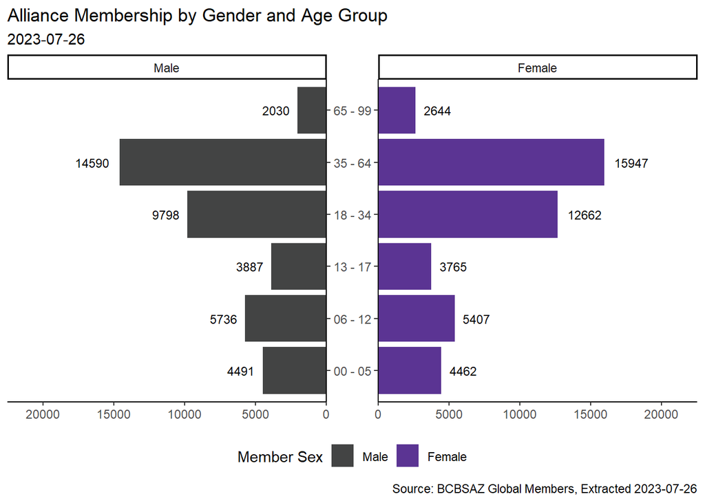

```r
#Make the pyramid plot
Fig_PopPyramid <- ggplot(DemoTable_SexByAgeGroup, aes(y = Age_Group, x = n, fill = sex)) +
   geom_bar(stat = "identity") +
   geom_text(aes(label = abs(n),
                 hjust = ifelse(
                   sex == "Female", -.3, 1.3)),
                 size = 3) +
   scale_fill_manual(values = c(Female = "#5b3493", Male = "#434444"), drop = FALSE) +
   facet_wrap(~sex, scales = "free") +
   facetted_pos_scales(
     x = list(
     scale_x_continuous(
       labels = abs, expand = c(0, 2500, 0, 0),
       limits = c(-20000, 0)),
     scale_x_continuous(
       expand = c(0, 0, 0, 2500),
       limits = c(0, 20000))),
     y = list(
       scale_y_discrete(position = "right"),
       scale_y_discrete(labels = NULL))) +
  labs(
    x = NULL,
    y = NULL,
    fill = "Member Sex",
    title = "Alliance Membership by Gender and Age Group",
    subtitle = Members_Report_Date,
    caption = "Source: BCBSAZ Global Members, Extracted 2023-07-26") +
  theme_classic() +
  theme(
    axis.text.y.right = element_text(
      margin = margin(0, 2.2, 0, 2.2)),
    legend.position = "bottom",
    legend.justification = "center",
    panel.spacing.x = unit(0, "pt"))

## Create Graphics
# Set the file path and name for saving the .png file
Report <- "./data/output/"
Report_Filename <- "2023-07-26_Fig_PopPyramid.png"

Dashboard <- "C:/Users/KGLtd/OneDrive - The NARBHA Institute/Site Assets/SitePages/Alliance-Dashboard/"
Dashboard_FileName1 <- "2023-07-26_Fig_PopPyramid.png"
Dashboard_FileName2 <- "Fig_PopPyramid.png"

# Save the ggplot as a .png file
# Report
ggsave(file.path(Report, Report_Filename), plot = Fig_PopPyramid, width = 6, height = 4, dpi = 300)

#Dashboard
ggsave(file.path(Dashboard, Dashboard_FileName1), plot = Fig_PopPyramid, width = 6, height = 4, dpi = 300)
ggsave(file.path(Dashboard, Dashboard_FileName2), plot = Fig_PopPyramid, width = 6, height = 4, dpi = 300)

Fig_PopPyramid
```

## Alliance Membership Allocation Information

Alliance Providers are assigned members at the beginning of each contract year. The Alliance supports member voice and choice, and as such provider assignment changes throughout the year in accordance with changing member needs and new enrollments. The following table describes the assignment by provider at the beginning of the contract year, and the current health plan auto-assignment by provider at the time of this reporting.

The *Alliance Allocation* represents the number of members for whom the providers are incentivised through the ACO. The *BCBSAZ Auto Assignment* represents the population of members for whose care the providers are responsible, and for whom they are measured.

As the COVID19 pandemic public health emergency (PHE), and the resulting restrictions on disenrollment of Medicaid recipients, is ended, we will monitor the rates of enrollment. It is estimated that 37,000 enrolled BCBSAZ members will lose coverage when the PHE ends. It is unknown how many of those will be Alliance members.

```r
# Wrangle contract allocation table for comparison
Alliance_AllocationTable <- AllianceProvAllocation |>
  filter(Provider_ShortName != "EHS") |>
  rename(AllianceAllocation = `Annual Member Months`) |>
  rename(Provider_ShortName = Provider) |>
  mutate(Provider_ShortName = if_else((
            Provider_ShortName == "Spectrum"),
            "SHG",
            Provider_ShortName)# the short name for spectrum varies depending on data source
         ) |>
  mutate(Provider_ShortName = if_else((
            Provider_ShortName == "WYGC"),
            "PH",
            Provider_ShortName)# the short name for spectrum varies depending on data source
         ) |>
  mutate(Provider_ShortName = if_else((
            Provider_ShortName == "SBH"),
            "SBHS",
            Provider_ShortName)# the short name for spectrum varies depending on data source
         )

# Export to CSV file
write.csv(Alliance_AllocationTable, "./data/output/2022-10-01_AllianceAllocationTable.csv")

# Using ActiveNAZMembership Wrangle BCBASAZ Auto Enrolled to filter and count members for Alliance Providers
HCA_AutoEnrolled <- ActiveNAZMmbrshp |>
  filter(bhhShortname != "EHS") |>
  count(bhhShortname) |>
  rename(HCA_Enrollment = n) |>
  rename(Provider_ShortName = bhhShortname)

# Export to CSV file, date is date of global members extract, date is first day of month data was pulled
write.csv(HCA_AutoEnrolled, "./data/output/2022-06-13_HCA_AutoEnrolled.csv")

# Create a table comparing auto-enrollment with contract allocation
# This is a Transparency Table for All Alliance Providers
ContractAlloc_v_Assignment <-
  merge(x=Alliance_AllocationTable, #NARBHA Contract Allocation
        y=HCA_AutoEnrolled, #HCA GlobalMembers Allocation
        by="Provider_ShortName") |>
  mutate(PercentDifference = percent(
    ((HCA_Enrollment-AllianceAllocation)/AllianceAllocation))) |>
  mutate(PercentOfMembership = percent(
    AllianceAllocation/(sum(AllianceAllocation))))

# Export the Alloc_v_Assignment table as a csv for reference, date is date of Progress Report
write.csv(ContractAlloc_v_Assignment, "./data/output/2023-07-26_ContractAlloc_v_Assignment.csv")
```

```r
Tab_Alloc_v_Assignment <- ContractAlloc_v_Assignment |>
  gt() |>
    tab_header(
      title = md("Alliance Provider Member Allocation"),
      subtitle = Members_Report_Date
      ) |>
    fmt_number(c(AllianceAllocation,
               HCA_Enrollment),
             rows = everything(),
             decimals = 0,
             sep_mark = ",") |>
    opt_align_table_header(align = "left") |>
    tab_source_note(
        source_note = md("*Alliance Allocation based on Contract Year 2022-2023*")
        ) |>
    # cols_width(Provider_ShortName ~ px(100),
    #           AllianceAllocation ~ px(115),
    #           HCA_Enrollment ~ px(115),
    #           PercentOfMembership ~ px(115),
    #          PercentDifference ~ px(115)) |>
    cols_label(Provider_ShortName = "Provider",
              AllianceAllocation = "Alliance Allocation",
              HCA_Enrollment = "BCBSAZ Auto Assignment",
              PercentOfMembership = "Percent of Membership",
             PercentDifference = "Percent Difference") |>
  tab_style(
    style = list(
      cell_fill(color = "#faede2"),
      cell_text(weight = "bold",
                color = "#14141c")
    ),
    locations = cells_column_labels(
      columns = everything()
    )
  ) |>
  opt_horizontal_padding(scale = 3)

# Creates graphics

# Report Output
gtsave(Tab_Alloc_v_Assignment, filename = "./data/output/2023-07-26_Tab_Alloc_v_Assignment.png")
gtsave(Tab_Alloc_v_Assignment, filename = "./data/output/2023-07-26_Tab_Alloc_v_Assignment.png")

# Dashboard
gtsave(Tab_Alloc_v_Assignment, filename = "C:/Users/KGLtd/OneDrive - The NARBHA Institute/Site Assets/SitePages/Alliance-Dashboard/2023-07-26_Tab_Alloc_v_Assignment.png")
gtsave(Tab_Alloc_v_Assignment, filename = "C:/Users/KGLtd/OneDrive - The NARBHA Institute/Site Assets/SitePages/Alliance-Dashboard/Alloc_v_Assignment.png")

Tab_Alloc_v_Assignment
```

Alliance Provider Member Allocation

2023-07-26

| Provider | Alliance Allocation | BCBSAZ Auto Assignment | Percent Difference | Percent of Membership |
| --- | --- | --- | --- | --- |
| CBI | 7,732 | 7,286 | -5.768% | 7.56% |
| CPIH | 16,718 | 15,534 | -7.082% | 16.36% |
| LCBHC | 5,129 | 4,734 | -7.701% | 5.02% |
| MMHC | 33,025 | 31,095 | -5.844% | 32.31% |
| PH | 9,151 | 9,497 | 3.781% | 8.95% |
| SBHS | 17,175 | 15,670 | -8.763% | 16.80% |
| SHG | 5,910 | 5,659 | -4.247% | 5.78% |
| TGC | 7,377 | 6,801 | -7.808% | 7.22% |

*Alliance Allocation based on Contract Year 2022-2023*

# Performance Measurement

## HEDIS Measures

The goal of the Alliance is to improve the Effectiveness of Care in the ACO community. WE focus on the following three domains; Follow Up after Hospitalization (FUH), Anti-depressant Medication Management (AMM), and Use of Opioids at High Dosage (HDO).

## NCQA Performance Measures, HEDIS My2023

```r
Domain <- c("Behavioral Health", "Behavioral Health","Behavioral Health", "Overuse/Approrpiateness")
Measure <- c("Antidepressant Medication (AMM), Effective Acute Phase Treatment",
             "Follow-Up After Hospitalization for Mental Illness (FUH),
             Follow-Up Within 7 Days Post-Discharge",
             "Follow-Up After Emergency Department Visit for Mental Illness (FUM). Not required by Contract",
             "Use of Opioids at High Dosage (HDO)")
NCQA_Mean <- c(.5729, .3936, .400, .9300)

AllianceMeasures_DF <- data.frame(Domain, Measure, NCQA_Mean)

AllianceMeasures_DF |>
  gt() |>
  tab_header(
      title = md("Alliance Performance Measures (NCQA)"),
      subtitle = Members_Report_Date
      ) |>
  fmt_percent(c(NCQA_Mean),
             rows = everything(),
             decimals = 2,
             sep_mark = ",") |>
  opt_align_table_header(align = "left") |>
  tab_style(
    style = list(
      cell_fill(color = "#faede2"),
      cell_text(weight = "bold",
                color = "#14141c")
    ),
    locations = cells_column_labels(
      columns = everything()
    )
  ) |>
  opt_horizontal_padding(scale = 3)
```

Alliance Performance Measures (NCQA)

2023-07-26

| Domain | Measure | NCQA_Mean |
| --- | --- | --- |
| Behavioral Health | Antidepressant Medication (AMM), Effective Acute Phase Treatment | 57.29% |
| Behavioral Health | Follow-Up After Hospitalization for Mental Illness (FUH), Follow-Up Within 7 Days Post-Discharge | 39.36% |
| Behavioral Health | Follow-Up After Emergency Department Visit for Mental Illness (FUM). Not required by Contract | 40.00% |
| Overuse/Approrpiateness | Use of Opioids at High Dosage (HDO) | 93.00% |

## Provider Performance

### All Alliance Performance

In order to report performance of the dependent variable, the Alliance Progress Report utilizes the VBP Validation Model [^1] data set. The monthly table *VBPQR_AllApsCombined_Cleaned_complete* is imported and transformed to summarize the aggregation for the individual providers and the entire Alliance ACO network.

```r
# 5/4/23 - Major updates to code because HCA changed the format of the VBP QR report.
# This process tarts with "VBP_Rep_Comb_validation_complete.csv" from the VBP Validation model

# Make the compliance/performance table. This is a summary table from the aggregated VBPQR.
# This is a transparency table that is available to Alliance Providers for their own assessment.
Tab_PercentCompliant <- VBP_Rep_Comb_validation_complete |>
  mutate(Compliant = if_else(`Gap Status` == "OPEN", 0, 1)) |>
  mutate(TotalEligible = if_else(`Gap Status` != 0, 1, 0)) |>
  rename("AdaptedCompliant" = Compliant) |>
  # mutate(AdaptedCompliant = if_else((`SubMeasure ID` == "AMM" & Compliant == 0), 0,
  #                 if_else((`SubMeasure ID` == "AMM" & Compliant == 1), 1,
  #                          if_else((`SubMeasure ID` == "FUH" & Compliant == 0), 0,
  #                                  if_else((`SubMeasure ID` == "FUH" & Compliant == 1), 1,
  #                                          if_else((`SubMeasure ID` == "FUM" & Compliant == 0), 0,
  #                                                 if_else((`SubMeasure ID` == "FUM" & Compliant == 1), 1,
  #                                                         if_else((`SubMeasure ID` == "HDO" & Compliant == 0), 1,
  #                                                               if_else((`SubMeasure ID` == "HDO" & Compliant == 1), 0, NA
  #
  #        ))))))))) |>
  #filter(`SubMeasure ID` %in% c("AMM","FUH", "HDO")) |>
  mutate(SumTotalEligible = sum(TotalEligible)) |>
  group_by(Provider_Shortname, `Health Home TIN & Name`, `SubMeasure ID`) |>
  summarize(AdaptedCompliant = sum(AdaptedCompliant),
            TotalEligible = sum(TotalEligible)) |>
  mutate(AdaptedNCQAMean = ifelse(`SubMeasure ID` == "AMM", .5729,
                                     ifelse(`SubMeasure ID` == "FUH", .3936,
                                            ifelse(`SubMeasure ID` == "FUM", .401,
                                                  ifelse(`SubMeasure ID` == "HDO", .9300,
                                                        ifelse(`SubMeasure ID` == "PCR", .100, NA
                                     )))))) |>
  mutate(PercentCompliant = as.numeric (AdaptedCompliant/TotalEligible)) |>
  mutate(PerformanceLevel = (PercentCompliant - AdaptedNCQAMean))

# Export the table as a csv for reference, date is date of progress report
write.csv(Tab_PercentCompliant, "./data/output/2023-07-26_Tab_PercentCompliant.csv")


# Calculate performance levels for All Alliance Performance Table/Figure
# This is the core table for network-wide statistics
# This is a Transparency Table for all Alliance Providers
AllAlliancePerformance <- Tab_PercentCompliant |>
  rename(SubMeasureID = `SubMeasure ID`) |>
  group_by(SubMeasureID) |>
  summarise(Sum_AdaptedCompliant = sum(AdaptedCompliant, na.rm = FALSE),
            Sum_TotalEligible = sum(TotalEligible, na.rm = FALSE)) |>
  mutate(Percent_Compliant = Sum_AdaptedCompliant/Sum_TotalEligible) |>
  mutate(NCQA_Mean = NCQA_MeanList) |>
  mutate(PerformanceLevel = (Percent_Compliant - NCQA_Mean))

# Export the table as a csv for reference, Date is date of progress report
write.csv(AllAlliancePerformance, "./data/output/2023-05-31_Tab_AllAlliancePerformance.csv")
```

```r
#All Alliance performance table
Tab_AllProvPerformance <- AllAlliancePerformance |>
gt() |>
  tab_header(
    title = md("Overall Performance of Alliance Provider Network"),
    subtitle = "Report as of 2023-07-26"
  ) |>
  fmt_percent(columns = c("Percent_Compliant", "NCQA_Mean"),
            decimals = 2,
            force_sign = FALSE) |>
  fmt_percent(columns = c("PerformanceLevel"),
              decimals = 2,
              force_sign = TRUE) |>
  opt_align_table_header(align = "left") |>
  cols_label(SubMeasureID = "NCQA Measure",
             Sum_AdaptedCompliant = "Compliant",
             Sum_TotalEligible = "Eligible",
             Percent_Compliant = "Percent Compliant",
             NCQA_Mean = "NCQA Mean",
             PerformanceLevel = "Performance Level"
             ) |>
   # cols_width(SubMeasureID ~ px(110),
   #           Sum_AdaptedCompliant ~ px(110),
   #           Sum_TotalEligible ~ px(110),
   #           Percent_Compliant ~ px(110),
   #           NCQA_Mean ~ px(110),
   #           PerformanceLevel ~ px(120)
   #           ) |>
  tab_source_note(
    source_note = md("*SOURCE: BCBSAZ VBP Performance Reports, Claims Adjudicated Through 2023-06-30* </br> *FUM not required by contract*")
  ) |>
  tab_style(
    style = list(
      cell_fill(color = "#faede2"),
      cell_text(weight = "bold",
                color = "#14141c")
    ),
    locations = cells_column_labels(
      columns = everything()
    )
  ) |>
  opt_horizontal_padding(scale = 3)

# Creates graphics

# Report Output
gtsave(Tab_AllProvPerformance, filename = "./data/output/2023-07-26_Tab_AllProvPerformance.png")
gtsave(Tab_AllProvPerformance, filename = "./data/output/2023-07-26_Tab_AllProvPerformance.png")

# Dashboard
gtsave(Tab_AllProvPerformance, filename = "C:/Users/KGLtd/OneDrive - The NARBHA Institute/Site Assets/SitePages/Alliance-Dashboard/2023-07-26_Tab_AllProvPerformance.png")
gtsave(Tab_AllProvPerformance, filename = "C:/Users/KGLtd/OneDrive - The NARBHA Institute/Site Assets/SitePages/Alliance-Dashboard/Tab_AllProvPerformance.png")

Tab_AllProvPerformance
```

Overall Performance of Alliance Provider Network

Report as of 2023-07-26

| NCQA Measure | Compliant | Eligible | Percent Compliant | NCQA Mean | Performance Level |
| --- | --- | --- | --- | --- | --- |
| AMM | 1090 | 1709 | 63.78% | 57.29% | +6.49% |
| FUH | 241 | 508 | 47.44% | 39.36% | +8.08% |
| FUM | 53 | 192 | 27.60% | 40.10% | −12.50% |
| HDO | 2428 | 2581 | 94.07% | 93.00% | +1.07% |

*SOURCE: BCBSAZ VBP Performance Reports, Claims Adjudicated Through 2023-06-30* *FUM not required by contract*

**Alliance Performance Levels**

- AMM: The overall performance score for AMM was 0.6377999 (0.0648999)
- FUH: The overall performance score for FUH was 0.4744094(0.0808094)
- HDO: The overall score for HDO was 0.9407207(0.0107207)

## Important

The figure below demonstrates The Alliance performance scores.

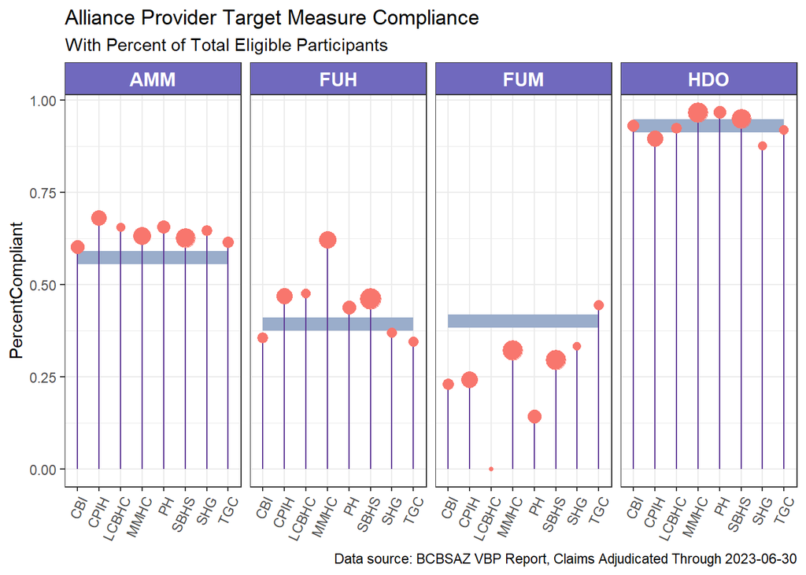

```r
# Target Measure Lollipop, most recent report
# Lollipop Chart

# Update the Tab_PercentCompliant table for the lollipop figure
Tab_AllProvLollipop <- Tab_PercentCompliant |>
  group_by(`SubMeasure ID`) |>
  mutate(SumTotalEligible = sum(TotalEligible)) |>
  mutate(PercentTotalEligible = TotalEligible/SumTotalEligible)

write.csv(Tab_AllProvLollipop, "./data/output/2023-07-26_Tab_AllProviderLollipop.csv")

write.csv(Tab_AllProvLollipop,"C:/Users/RyanK/OneDrive - The NARBHA Institute/Documents - Data Force/Projects/AllianceIntranetSupport/data/Tab_AllProviderLollipop.csv")

#make the lollipops
Fig_AllProvLollipop <- Tab_AllProvLollipop |>
  ggplot(aes(x = Provider_Shortname,
             y = PercentCompliant
             )) +
  geom_line(aes(y = AdaptedNCQAMean,
                group = `SubMeasure ID`),
                color = "#9aadcb",
            size = 4
            ) +
  geom_segment(aes(xend = Provider_Shortname,
                   y = 0,
                   yend = PercentCompliant),
                   color = "#5b3493"
               )+
  geom_point(aes(y = PercentCompliant,
                 size = PercentTotalEligible
                ,
                colour = "#5b3493")
             )+
  facet_grid(cols = vars(`SubMeasure ID`)
             )+
  theme_bw()+
  theme(legend.position = "none",
        axis.text.x = element_text(
          angle = 65,
          hjust=1),
        axis.title.x = element_blank(),
        axis.line = element_blank(),
        strip.background = element_rect(
          fill = "#7069be"),
        strip.text.x = element_text(size = 12,
                                    color = "#FFFFFF",
                                    face = "bold"))+
  #scale_y_continuous(labels = scales::percent)+
 # ylim(c(0,1))+
  labs(title = "Alliance Provider Target Measure Compliance",
       subtitle = "With Percent of Total Eligible Participants",
       caption = "Data source: BCBSAZ VBP Report, Claims Adjudicated Through 2023-06-30")

## Create Graphics
# Set the file path and name for saving the .png file
Report <- "./data/output/"
Report_Filename <- "2023-07-26_Fig_AllProvLollipop.png"

Dashboard <- "C:/Users/KGLtd/OneDrive - The NARBHA Institute/Site Assets/SitePages/Alliance-Dashboard/"
Dashboard_FileName1 <- "2023-07-26_Fig_AllProvLollipop.png"
Dashboard_FileName2 <- "Fig_AllProvLollipop.png"

# Save the ggplot as a .png file
# Report
ggsave(file.path(Report, Report_Filename), plot = Fig_AllProvLollipop, width = 6, height = 4, dpi = 300)

# Dashboard
ggsave(file.path(Dashboard, Dashboard_FileName1), plot = Fig_AllProvLollipop, width = 6, height = 4, dpi = 300)
ggsave(file.path(Dashboard, Dashboard_FileName2), plot = Fig_AllProvLollipop, width = 6, height = 4, dpi = 300)

Fig_AllProvLollipop
```

### A Closer Look

#### AMM

```r
# Calculate performance levels
# AMM2
IndivAlliancePerformance_AMM2 <- Tab_PercentCompliant |>
  filter(`SubMeasure ID` == "AMM") |>
  select(Provider_Shortname,
         TotalEligible,
         AdaptedCompliant,
         PercentCompliant,
         PerformanceLevel)

# Export the table as a csv for reference, date is date of progress report

write.csv(IndivAlliancePerformance_AMM2, "./data/output/2023-07-26_IndivAlliancePerformance_AMM2.csv")
```

```r
#All Alliance performance table
Tab_IndivAlliancePerformance_AMM2 <-
IndivAlliancePerformance_AMM2 [ , -1 ] |>
  group_by("Provider_Shortname") |>
gt() |>
  tab_header(
    title = "Performance of Alliance Provider Network (AMM)",
    subtitle = c(Reportasof, "NCQA Mean = 57.29%")
  ) |>
  # fmt_percent(columns = c("Percent_Compliant", "NCQA_Mean"),
  #           decimals = 2,
  #           force_sign = FALSE) |>
  fmt_percent(columns = c("PerformanceLevel"),
              decimals = 2,
              force_sign = TRUE) |>
  fmt_percent(columns = c("PercentCompliant"),
              decimals = 2,
              force_sign = FALSE) |>
  opt_align_table_header(align = "left") |>
  cols_label(
             Provider_Shortname = "Provider",
             AdaptedCompliant = "Compliant",
             TotalEligible = "Eligible",
             PercentCompliant = "Percent Compliant",
             PerformanceLevel = "Performance Level"
             ) |>
   # cols_width(
   #           # SubMeasureID ~ px(110),
   #           AdaptedCompliant ~ px(110),
   #           TotalEligible ~ px(110),
   #           PercentCompliant ~ px(110),
   #           # NCQA_Mean ~ px(110),
   #           PerformanceLevel ~ px(120)
   #           ) |>
  tab_source_note(
    source_note = md("*SOURCE: BCBSAZ VBP Quality Roster, Claims Adjudicated Through 2023-06-30*")
  ) |>
  tab_style(
    style = list(
      cell_fill(color = "#faede2"),
      cell_text(weight = "bold",
                color = "#14141c")
    ),
    locations = cells_column_labels(
      columns = everything()
    )
  ) |>
  opt_horizontal_padding(scale = 3)

# Creates graphics

# Report Output
gtsave(Tab_IndivAlliancePerformance_AMM2, filename = "./data/output/2023-07-26_Tab_IndivAlliancePerformance_AMM2.png")
gtsave(Tab_IndivAlliancePerformance_AMM2, filename = "./data/output/2023-07-26_Tab_IndivAlliancePerformance_AMM2.png")

# Dashboard
gtsave(Tab_IndivAlliancePerformance_AMM2, filename = "C:/Users/KGLtd/OneDrive - The NARBHA Institute/Site Assets/SitePages/Alliance-Dashboard/2023-07-26_Tab_IndivAlliancePerformance_AMM2.png")
gtsave(Tab_IndivAlliancePerformance_AMM2, filename = "C:/Users/KGLtd/OneDrive - The NARBHA Institute/Site Assets/SitePages/Alliance-Dashboard/Tab_IndivAlliancePerformance_AMM2.png")

Tab_IndivAlliancePerformance_AMM2
```

Performance of Alliance Provider Network (AMM)

2023-07-21 NCQA Mean = 57.29%

| Provider | Eligible | Compliant | Percent Compliant | Performance Level |
| --- | --- | --- | --- | --- |
| Provider_Shortname |  |  |  |  |
| CBI | 191 | 115 | 60.21% | +2.92% |
| CPIH | 260 | 177 | 68.08% | +10.79% |
| LCBHC | 67 | 44 | 65.67% | +8.38% |
| MMHC | 361 | 228 | 63.16% | +5.87% |
| PH | 169 | 111 | 65.68% | +8.39% |
| SBHS | 442 | 277 | 62.67% | +5.38% |
| SHG | 102 | 66 | 64.71% | +7.42% |
| TGC | 117 | 72 | 61.54% | +4.25% |

*SOURCE: BCBSAZ VBP Quality Roster, Claims Adjudicated Through 2023-06-30*

#### FUH

```r
# Calculate performance levels
# FUH
IndivAlliancePerformance_FUH7 <- Tab_PercentCompliant |>
  filter(`SubMeasure ID` == "FUH") |>
  select(Provider_Shortname,
         TotalEligible,
         AdaptedCompliant,
         PercentCompliant,
         PerformanceLevel)

# Export the table as a csv for reference, date is date of progress report

write.csv(IndivAlliancePerformance_FUH7, "./data/output/2023-07-26_IndivAlliancePerformance_FUH7.csv")
```

```r
#All Alliance performance table

Tab_IndivAlliancePerformance_FUH7 <-
IndivAlliancePerformance_FUH7 [ , -1 ] |>
  group_by("Provider_Shortname") |>
gt() |>
  tab_header(
    title = "Performance of Alliance Provider Network (FUH)",
    subtitle = c(Reportasof, "NCQA Mean = 39.36%")
  ) |>
  # fmt_percent(columns = c("Percent_Compliant", "NCQA_Mean"),
  #           decimals = 2,
  #           force_sign = FALSE) |>
  fmt_percent(columns = c("PerformanceLevel"),
              decimals = 2,
              force_sign = TRUE) |>
  fmt_percent(columns = c("PercentCompliant"),
              decimals = 2,
              force_sign = FALSE) |>
  opt_align_table_header(align = "left") |>
  cols_label(
             Provider_Shortname = "Provider",
             AdaptedCompliant = "Compliant",
             TotalEligible = "Eligible",
             PercentCompliant = "Percent Compliant",
             PerformanceLevel = "Performance Level"
             ) |>
   # cols_width(
   #           # SubMeasureID ~ px(110),
   #           AdaptedCompliant ~ px(110),
   #           TotalEligible ~ px(110),
   #           PercentCompliant ~ px(110),
   #           # NCQA_Mean ~ px(110),
   #           PerformanceLevel ~ px(120)
   #           ) |>
  tab_source_note(
    source_note = md("*SOURCE: BCBSAZ VBP Quality Roster, Claims Adjudicated Through 2023-06-30*")
  ) |>
  tab_style(
    style = list(
      cell_fill(color = "#faede2"),
      cell_text(weight = "bold",
                color = "#14141c")
    ),
    locations = cells_column_labels(
      columns = everything()
    )
  ) |>
  opt_horizontal_padding(scale = 3)

# Report Output
gtsave(Tab_IndivAlliancePerformance_FUH7, filename = "./data/output/2023-07-26_Tab_IndivAlliancePerformance_FUH7.png")
gtsave(Tab_IndivAlliancePerformance_FUH7, filename = "./data/output/2023-07-26_Tab_IndivAlliancePerformance_FUH7.png")

# Dashboard
gtsave(Tab_IndivAlliancePerformance_FUH7, filename = "C:/Users/KGLtd/OneDrive - The NARBHA Institute/Site Assets/SitePages/Alliance-Dashboard/2023-07-26_Tab_IndivAlliancePerformance_FUH7.png")
gtsave(Tab_IndivAlliancePerformance_FUH7, filename = "C:/Users/KGLtd/OneDrive - The NARBHA Institute/Site Assets/SitePages/Alliance-Dashboard/Tab_IndivAlliancePerformance_FUH7.png")

Tab_IndivAlliancePerformance_FUH7
```

Performance of Alliance Provider Network (FUH)

2023-07-21 NCQA Mean = 39.36%

| Provider | Eligible | Compliant | Percent Compliant | Performance Level |
| --- | --- | --- | --- | --- |
| Provider_Shortname |  |  |  |  |
| CBI | 31 | 11 | 35.48% | −3.88% |
| CPIH | 83 | 39 | 46.99% | +7.63% |
| LCBHC | 21 | 10 | 47.62% | +8.26% |
| MMHC | 98 | 61 | 62.24% | +22.88% |
| PH | 57 | 25 | 43.86% | +4.50% |
| SBHS | 165 | 76 | 46.06% | +6.70% |
| SHG | 27 | 10 | 37.04% | −2.32% |
| TGC | 26 | 9 | 34.62% | −4.74% |

*SOURCE: BCBSAZ VBP Quality Roster, Claims Adjudicated Through 2023-06-30*

#### HDO

```r
# Calculate performance levels
# HDO
IndivAlliancePerformance_HDO <- Tab_PercentCompliant |>
  filter(`SubMeasure ID` == "HDO") |>
  select(Provider_Shortname,
         TotalEligible,
         AdaptedCompliant,
         PercentCompliant,
         PerformanceLevel)

# Export the table as a csv for reference, date is date of progress report

write.csv(IndivAlliancePerformance_HDO, "./data/output/2023-07-26_IndivAlliancePerformance_HDO.csv")
```

```r
#All Alliance performance table
Tab_IndivAlliancePerformance_HDO <-
IndivAlliancePerformance_HDO [ , -1 ] |>
  group_by("Provider_Shortname") |>
gt() |>
  tab_header(
    title = "Performance of Alliance Provider Network (HDO)",
    subtitle = c(Reportasof, "NCQA Mean = 93.00%")
  ) |>
  # fmt_percent(columns = c("Percent_Compliant", "NCQA_Mean"),
  #           decimals = 2,
  #           force_sign = FALSE) |>
  fmt_percent(columns = c("PerformanceLevel"),
              decimals = 2,
              force_sign = TRUE) |>
  fmt_percent(columns = c("PercentCompliant"),
              decimals = 2,
              force_sign = FALSE) |>
  opt_align_table_header(align = "left") |>
  cols_label(
             Provider_Shortname = "Provider",
             AdaptedCompliant = "Compliant",
             TotalEligible = "Eligible",
             PercentCompliant = "Percent Compliant",
             PerformanceLevel = "Performance Level"
             ) |>
   # cols_width(
   #           # SubMeasureID ~ px(110),
   #           AdaptedCompliant ~ px(110),
   #           TotalEligible ~ px(110),
   #           PercentCompliant ~ px(110),
   #           # NCQA_Mean ~ px(110),
   #           PerformanceLevel ~ px(120)
   #           ) |>
  tab_source_note(
    source_note = md("*SOURCE: BCBSAZ VBP Quality Roster, Claims Adjudicated Through 2023-06-30*")
  ) |>
  tab_style(
    style = list(
      cell_fill(color = "#faede2"),
      cell_text(weight = "bold",
                color = "#14141c")
    ),
    locations = cells_column_labels(
      columns = everything()
    )
  ) |>
  opt_horizontal_padding(scale = 3)

# Report Output
gtsave(Tab_IndivAlliancePerformance_HDO, filename = "./data/output/2023-07-26_Tab_IndivAlliancePerformance_HDO.png")
gtsave(Tab_IndivAlliancePerformance_HDO, filename = "./data/output/2023-07-26_Tab_IndivAlliancePerformance_HDO.png")

# Dashboard
gtsave(Tab_IndivAlliancePerformance_HDO, filename = "C:/Users/KGLtd/OneDrive - The NARBHA Institute/Site Assets/SitePages/Alliance-Dashboard/2023-07-26_Tab_IndivAlliancePerformance_HDO.png")
gtsave(Tab_IndivAlliancePerformance_HDO, filename = "C:/Users/KGLtd/OneDrive - The NARBHA Institute/Site Assets/SitePages/Alliance-Dashboard/Tab_IndivAlliancePerformance_HDO.png")

Tab_IndivAlliancePerformance_HDO
```

Performance of Alliance Provider Network (HDO)

2023-07-21 NCQA Mean = 93.00%

| Provider | Eligible | Compliant | Percent Compliant | Performance Level |
| --- | --- | --- | --- | --- |
| Provider_Shortname |  |  |  |  |
| CBI | 187 | 174 | 93.05% | +0.05% |
| CPIH | 406 | 364 | 89.66% | −3.34% |
| LCBHC | 144 | 133 | 92.36% | −0.64% |
| MMHC | 742 | 717 | 96.63% | +3.63% |
| PH | 212 | 205 | 96.70% | +3.70% |
| SBHS | 680 | 646 | 95.00% | +2.00% |
| SHG | 98 | 86 | 87.76% | −5.24% |
| TGC | 112 | 103 | 91.96% | −1.04% |

*SOURCE: BCBSAZ VBP Quality Roster, Claims Adjudicated Through 2023-06-30*

## Footnotes

[^1]: Kivela, John Ryan. (2023). Value Based Purchasing Validation Model. The Alliance ACO.